# Part II - Ford GoBike System Data

## by Riga

## Investigation Overview

### Goal of project:

The purpose of this presentation is to investigate and understand the relationship between riding duration and the number of users, considering various personal information factors such as gender, age, and user type, as well as the impact of station location on these variables. By exploring these relationships, we aim to gain insights into how different factors influence the number of users and the duration of their rides. This analysis will provide valuable information on user behavior and preferences, which can help in making informed decisions and improving the overall bike-sharing system.

### Summary of Key Insights:

Based on the plot and analysis, the analyzed factors, including personal information (gender, age, and user type) and station location, have a significant impact on the number of users, but they show relatively little effect on ride duration.

### Dataset Overview

The dataset is consists of 183412 rows and 16 columns. The column 'duration_sec' represents the time of each bike trip; The column 'start_time' and 'end_time' indicate the data and time of each trip at starting and end points; The column 'start_station_id', 'end_station_id', 'start_station_name','end__station_name' denote the station IDs and names at the starting and end station. Their geological information is provided by column 'start_station_latitude','start_station_longitude','end_station_latitude' and 'end_station_longitude'; The column 'bike_id' is the ID of the bike; The personal information contains users' age, gender, user type can be gotten from columns 'member_birth_year', 'member_gender','user_type'; The last column 'bike_share_for_all_trip' shows if the shared bike has been used for the whole trip.

## 1. Relation of duration time and number of users based on gender and user type

### (1) Plot based on gender:

- The analysis indicates that gender and user type have a significant impact on the number of users but show relatively little influence on the ride duration, which remains concentrated within specific ranges.
- Male users dominate the chart, with a peak count of around 12,000 users and durations from 5 to 10 minutes. Female and other genders also show peaks in this duration range, but with lower user counts.

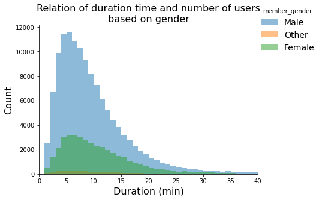

### (2) Plot based on user type:

- Subscribers form the majority of users, and both customer and subscriber groups have peak duration times within the 5 to 10-minute range.

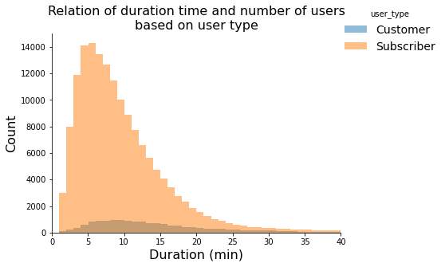

## 2. Relation of duration time and number of users based on age distribution

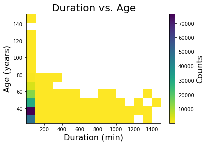

## 3. Relation of duration time and number of users based on top 10 popular stations

- The complex bar plot matrix, focusing on the top 10 popular stations, provides a comprehensive view of the distribution of the number of users against ride duration for both start and end stations. The y-axis exhibits substantial variations in individual counts across different stations, with peak values ranging from around 750 to over 2000 people. Simultaneously, the x-axis representing the duration time predominantly concentrates within the 0 to 30-minute range. This visualization demonstrates that station location has a significant impact on the number of users but has relatively little effect on the ride duration, as the majority of durations are confined within a specific time frame regardless of the station location.

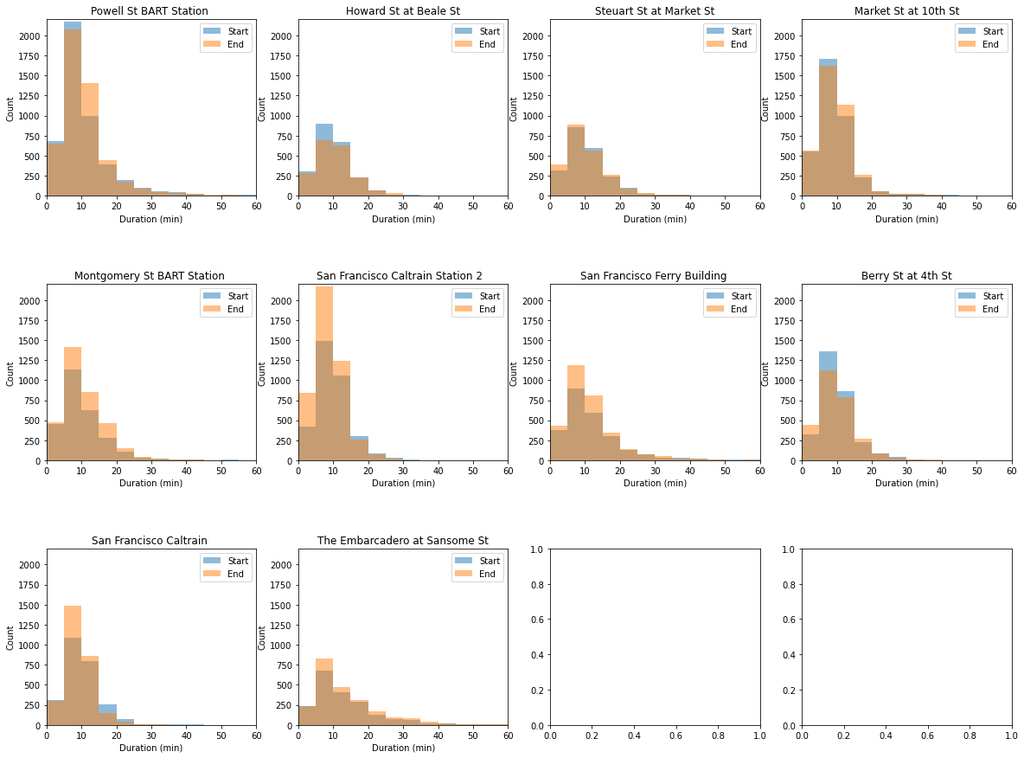